# R Notebook

```r
library(tidyverse)
library(janitor)
library(lubridate)
library(ggfortify)
library(GGally)
library(leaps)
library(modelr)
```

```r
avocados_tidy_no_region <- read_csv(here::here("data/clean_avocado.csv"))
```

```r
automodel <- regsubsets(average_price ~.,
                                 data = avocados_tidy_no_region,
                                 nvmax = 8,
                                 method = "exhaustive")

sum_forward <- summary(automodel)

sum_forward
```

```
Subset selection object
Call: regsubsets.formula(average_price ~ ., data = avocados_tidy_no_region,
    nvmax = 8, method = "exhaustive")
27 Variables  (and intercept)
                   Forced in Forced out
total_volume           FALSE      FALSE
small_sold             FALSE      FALSE
large_sold             FALSE      FALSE
x_large_sold           FALSE      FALSE
total_bags             FALSE      FALSE
small_bags             FALSE      FALSE
large_bags             FALSE      FALSE
x_large_bags           FALSE      FALSE
typeorganic            FALSE      FALSE
year                   FALSE      FALSE
monthAugust            FALSE      FALSE
monthDecember          FALSE      FALSE
monthFebruary          FALSE      FALSE
monthJanuary           FALSE      FALSE
monthJuly              FALSE      FALSE
monthJune              FALSE      FALSE
monthMarch             FALSE      FALSE
monthMay               FALSE      FALSE
monthNovember          FALSE      FALSE
monthOctober           FALSE      FALSE
monthSeptember         FALSE      FALSE
ratio_small_sold       FALSE      FALSE
ratio_large_sold       FALSE      FALSE
ratio_x_large_sold     FALSE      FALSE
ratio_small_bags       FALSE      FALSE
ratio_large_bags       FALSE      FALSE
ratio_x_large_bags     FALSE      FALSE
1 subsets of each size up to 8
Selection Algorithm: exhaustive
         total_volume small_sold large_sold x_large_sold
1  ( 1 ) " "          " "        " "        " "
2  ( 1 ) " "          " "        " "        " "
3  ( 1 ) " "          " "        " "        " "
4  ( 1 ) " "          " "        " "        " "
5  ( 1 ) " "          " "        " "        " "
```

[output cut: 51 more lines]

```
3  ( 1 ) " "                " "              "*"
4  ( 1 ) " "                " "              "*"
5  ( 1 ) " "                " "              "*"
6  ( 1 ) " "                " "              "*"
7  ( 1 ) " "                " "              "*"
8  ( 1 ) " "                " "              "*"
         ratio_x_large_bags
1  ( 1 ) " "
2  ( 1 ) " "
3  ( 1 ) " "
4  ( 1 ) " "
5  ( 1 ) " "
6  ( 1 ) " "
7  ( 1 ) " "
8  ( 1 ) " "
```

As an exploratory glance models including type, ratio_large_bags, ratio_large_sold, ratio_small_sold, month and year.

```r
sum_forward2
```

```
Subset selection object
Call: regsubsets.formula(average_price ~ ., data = avocados_tidy, nvmax = 8,
    method = "forward")
80 Variables  (and intercept)
                          Forced in Forced out
total_volume                  FALSE      FALSE
small_sold                    FALSE      FALSE
large_sold                    FALSE      FALSE
x_large_sold                  FALSE      FALSE
total_bags                    FALSE      FALSE
small_bags                    FALSE      FALSE
large_bags                    FALSE      FALSE
x_large_bags                  FALSE      FALSE
typeorganic                   FALSE      FALSE
year                          FALSE      FALSE
regionAtlanta                 FALSE      FALSE
regionBaltimoreWashington     FALSE      FALSE
regionBoise                   FALSE      FALSE
regionBoston                  FALSE      FALSE
regionBuffaloRochester        FALSE      FALSE
regionCalifornia              FALSE      FALSE
regionCharlotte               FALSE      FALSE
regionChicago                 FALSE      FALSE
regionCincinnatiDayton        FALSE      FALSE
regionColumbus                FALSE      FALSE
regionDallasFtWorth           FALSE      FALSE
regionDenver                  FALSE      FALSE
regionDetroit                 FALSE      FALSE
regionGrandRapids             FALSE      FALSE
regionGreatLakes              FALSE      FALSE
regionHarrisburgScranton      FALSE      FALSE
regionHartfordSpringfield     FALSE      FALSE
regionHouston                 FALSE      FALSE
regionIndianapolis            FALSE      FALSE
regionJacksonville            FALSE      FALSE
regionLasVegas                FALSE      FALSE
regionLosAngeles              FALSE      FALSE
regionLouisville              FALSE      FALSE
regionMiamiFtLauderdale       FALSE      FALSE
regionMidsouth                FALSE      FALSE
```

[output cut: 266 more lines]

```
3  ( 1 ) " "              "*"              " "
4  ( 1 ) " "              "*"              " "
5  ( 1 ) " "              "*"              " "
6  ( 1 ) " "              "*"              " "
7  ( 1 ) " "              "*"              " "
8  ( 1 ) " "              "*"              " "
         ratio_small_bags ratio_large_bags ratio_x_large_bags
1  ( 1 ) " "              " "              " "
2  ( 1 ) " "              " "              " "
3  ( 1 ) " "              "*"              " "
4  ( 1 ) " "              "*"              " "
5  ( 1 ) " "              "*"              " "
6  ( 1 ) " "              "*"              " "
7  ( 1 ) " "              "*"              " "
8  ( 1 ) " "              "*"              " "
```

When leaving region in only Houston was identified as an input by the automodel.

# 1st round of modeling

*Type has a 0.38 r^2. A good starting point would be to build a model based on type*

```r
model1a <- lm(average_price ~ type, avocados_tidy_no_region)
summary(model1a)
```

```
Call:
lm(formula = average_price ~ type, data = avocados_tidy_no_region)

Residuals:
     Min       1Q   Median       3Q      Max
-1.21400 -0.20400 -0.02804  0.18600  1.59600

Coefficients:
            Estimate Std. Error t value Pr(>|t|)
(Intercept) 1.158040   0.003321   348.7   <2e-16 ***
typeorganic 0.495959   0.004697   105.6   <2e-16 ***
---
Signif. codes:  0 ‘***’ 0.001 ‘**’ 0.01 ‘*’ 0.05 ‘.’ 0.1 ‘ ’ 1

Residual standard error: 0.3173 on 18247 degrees of freedom
Multiple R-squared:  0.3793,    Adjusted R-squared:  0.3792
F-statistic: 1.115e+04 on 1 and 18247 DF,  p-value: < 2.2e-16
```

```r
model1b <- lm(average_price ~ ratio_small_sold, avocados_tidy_no_region)
summary(model1b)
```

```
Call:
lm(formula = average_price ~ ratio_small_sold, data = avocados_tidy_no_region)

Residuals:
     Min       1Q   Median       3Q      Max
-1.10864 -0.27728 -0.04636  0.22812  1.88678

Coefficients:
                  Estimate Std. Error t value Pr(>|t|)
(Intercept)       1.550886   0.004067  381.30   <2e-16 ***
ratio_small_sold -0.643503   0.013095  -49.14   <2e-16 ***
---
Signif. codes:  0 ‘***’ 0.001 ‘**’ 0.01 ‘*’ 0.05 ‘.’ 0.1 ‘ ’ 1

Residual standard error: 0.3784 on 18247 degrees of freedom
Multiple R-squared:  0.1169,    Adjusted R-squared:  0.1168
F-statistic:  2415 on 1 and 18247 DF,  p-value: < 2.2e-16
```

```r
model1c <- lm(average_price ~ ratio_large_sold, avocados_tidy_no_region)
summary(model1c)
```

```
Call:
lm(formula = average_price ~ ratio_large_sold, data = avocados_tidy_no_region)

Residuals:
     Min       1Q   Median       3Q      Max
-0.91762 -0.31101 -0.04026  0.25657  1.84968

Coefficients:
                 Estimate Std. Error t value Pr(>|t|)
(Intercept)      1.313026   0.005256  249.80   <2e-16 ***
ratio_large_sold 0.267572   0.012534   21.35   <2e-16 ***
---
Signif. codes:  0 ‘***’ 0.001 ‘**’ 0.01 ‘*’ 0.05 ‘.’ 0.1 ‘ ’ 1

Residual standard error: 0.3978 on 18247 degrees of freedom
Multiple R-squared:  0.02437,   Adjusted R-squared:  0.02431
F-statistic: 455.7 on 1 and 18247 DF,  p-value: < 2.2e-16
```

```r
model1d <- lm(average_price ~ total_volume, avocados_tidy_no_region)
summary(model1d)
```

```
Call:
lm(formula = average_price ~ total_volume, data = avocados_tidy_no_region)

Residuals:
     Min       1Q   Median       3Q      Max
-0.98366 -0.29994 -0.03319  0.25498  1.82528

Coefficients:
               Estimate Std. Error t value Pr(>|t|)
(Intercept)   1.425e+00  3.012e-03  473.07   <2e-16 ***
total_volume -2.247e-08  8.470e-10  -26.54   <2e-16 ***
---
Signif. codes:  0 ‘***’ 0.001 ‘**’ 0.01 ‘*’ 0.05 ‘.’ 0.1 ‘ ’ 1

Residual standard error: 0.3951 on 18247 degrees of freedom
Multiple R-squared:  0.03715,   Adjusted R-squared:  0.0371
F-statistic: 704.1 on 1 and 18247 DF,  p-value: < 2.2e-16
```

```r
model1e <- lm(average_price ~ year, avocados_tidy_no_region)
summary(model1e)
```

```
Call:
lm(formula = average_price ~ year, data = avocados_tidy_no_region)

Residuals:
     Min       1Q   Median       3Q      Max
-1.00000 -0.30007 -0.04007  0.25985  1.84993

Coefficients:
              Estimate Std. Error t value Pr(>|t|)
(Intercept) -79.091294   6.366332  -12.42   <2e-16 ***
year          0.039926   0.003158   12.64   <2e-16 ***
---
Signif. codes:  0 ‘***’ 0.001 ‘**’ 0.01 ‘*’ 0.05 ‘.’ 0.1 ‘ ’ 1

Residual standard error: 0.4009 on 18247 degrees of freedom
Multiple R-squared:  0.008686,  Adjusted R-squared:  0.008631
F-statistic: 159.9 on 1 and 18247 DF,  p-value: < 2.2e-16
```

Autoplot doesn’t help much for a 2 option variable but normal Q-Q looks normal enough.

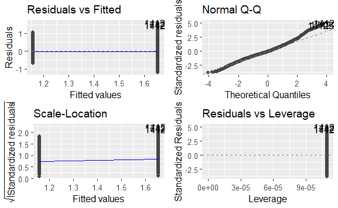

```r
autoplot(model1a)
```

```r
NA
NA
```

From this part of the ggpairs on the residual data it would be good to look at small sold, large bags and total_volume

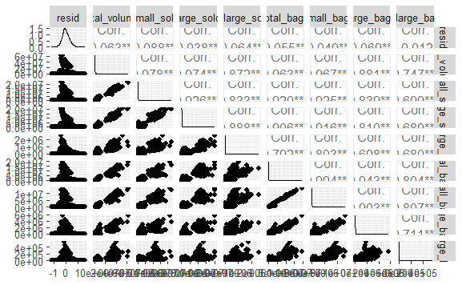

```r
price_resid <- avocados_tidy_no_region %>%
  add_residuals(model1a) %>%
  add_predictions(model1a) %>%
  select(-average_price, -type)

price_resid %>%
  select(resid, total_volume:x_large_bags) %>%
  ggpairs()
```

4 very promising categories here for ratio small/large and bags small/large.

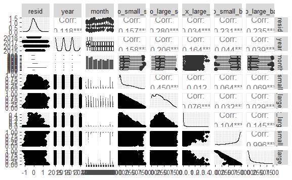

# 2nd round of modeling

```r
model2a <- lm(average_price ~ type + ratio_large_sold, avocados_tidy_no_region)
summary(model2a)
```

```
Call:
lm(formula = average_price ~ type + ratio_large_sold, data = avocados_tidy_no_region)

Residuals:
     Min       1Q   Median       3Q      Max
-1.11897 -0.19821 -0.02818  0.18441  1.62894

Coefficients:
                 Estimate Std. Error t value Pr(>|t|)
(Intercept)      1.015906   0.004799  211.68   <2e-16 ***
typeorganic      0.514731   0.004532  113.57   <2e-16 ***
ratio_large_sold 0.382131   0.009647   39.61   <2e-16 ***
---
Signif. codes:  0 ‘***’ 0.001 ‘**’ 0.01 ‘*’ 0.05 ‘.’ 0.1 ‘ ’ 1

Residual standard error: 0.3045 on 18246 degrees of freedom
Multiple R-squared:  0.4284,    Adjusted R-squared:  0.4284
F-statistic:  6838 on 2 and 18246 DF,  p-value: < 2.2e-16
```

```r
model2a <- lm(average_price ~ type + ratio_small_sold, avocados_tidy_no_region)
summary(model2a)
```

```
Call:
lm(formula = average_price ~ type + ratio_small_sold, data = avocados_tidy_no_region)

Residuals:
     Min       1Q   Median       3Q      Max
-1.25291 -0.19430 -0.03179  0.18126  1.59329

Coefficients:
                  Estimate Std. Error t value Pr(>|t|)
(Intercept)       1.238252   0.004779  259.08   <2e-16 ***
typeorganic       0.455590   0.004951   92.02   <2e-16 ***
ratio_small_sold -0.266584   0.011572  -23.04   <2e-16 ***
---
Signif. codes:  0 ‘***’ 0.001 ‘**’ 0.01 ‘*’ 0.05 ‘.’ 0.1 ‘ ’ 1

Residual standard error: 0.3128 on 18246 degrees of freedom
Multiple R-squared:  0.3968,    Adjusted R-squared:  0.3967
F-statistic:  6002 on 2 and 18246 DF,  p-value: < 2.2e-16
```

```r
model2a <- lm(average_price ~ type + ratio_small_bags, avocados_tidy_no_region)
summary(model2a)
```

```
Call:
lm(formula = average_price ~ type + ratio_small_bags, data = avocados_tidy_no_region)

Residuals:
     Min       1Q   Median       3Q      Max
-1.02962 -0.19731 -0.03505  0.17325  1.52374

Coefficients:
                 Estimate Std. Error t value Pr(>|t|)
(Intercept)      0.955699   0.007067  135.22   <2e-16 ***
typeorganic      0.511118   0.004594  111.25   <2e-16 ***
ratio_small_bags 0.259444   0.008061   32.19   <2e-16 ***
---
Signif. codes:  0 ‘***’ 0.001 ‘**’ 0.01 ‘*’ 0.05 ‘.’ 0.1 ‘ ’ 1

Residual standard error: 0.3085 on 18231 degrees of freedom
  (15 observations deleted due to missingness)
Multiple R-squared:  0.4125,    Adjusted R-squared:  0.4124
F-statistic:  6400 on 2 and 18231 DF,  p-value: < 2.2e-16
```

```r
model2a <- lm(average_price ~ type + ratio_large_bags, avocados_tidy_no_region)
summary(model2a)
```

```
Call:
lm(formula = average_price ~ type + ratio_large_bags, data = avocados_tidy_no_region)

Residuals:
     Min       1Q   Median       3Q      Max
-1.02530 -0.19796 -0.03495  0.17204  1.52204

Coefficients:
                  Estimate Std. Error t value Pr(>|t|)
(Intercept)       1.212487   0.003624  334.56   <2e-16 ***
typeorganic       0.515470   0.004603  111.99   <2e-16 ***
ratio_large_bags -0.265529   0.008064  -32.93   <2e-16 ***
---
Signif. codes:  0 ‘***’ 0.001 ‘**’ 0.01 ‘*’ 0.05 ‘.’ 0.1 ‘ ’ 1

Residual standard error: 0.3081 on 18231 degrees of freedom
  (15 observations deleted due to missingness)
Multiple R-squared:  0.414, Adjusted R-squared:  0.4139
F-statistic:  6439 on 2 and 18231 DF,  p-value: < 2.2e-16
```

[figure not shown]

Best additional item to fit to the data is ratio_large_sold. This can be an alias for ratio small_sold and ratio_x_large_sold, if one of these is added as a best fit the other must be removed. Likewise large_sold may not add much with this variable already in place.

```r
price_resid_2 <- avocados_tidy_no_region %>%
  add_residuals(model2a) %>%
  add_predictions(model2a) %>%
  select(-average_price, -type, - ratio_large_sold)

price_resid_2 %>%
  select(resid, total_volume:x_large_bags) %>%
  ggpairs()
```

[output not shown]

```r
price_resid_2 %>%
  select(resid, year:ratio_x_large_bags) %>%
  ggpairs()
```

[output not shown]

# 3rd round of modeling

```r
model3a <- lm(average_price ~ type + ratio_large_sold + ratio_small_sold, avocados_tidy_no_region)
summary(model3a)
```

```
Call:
lm(formula = average_price ~ type + ratio_large_sold + ratio_small_sold,
    data = avocados_tidy_no_region)

Residuals:
     Min       1Q   Median       3Q      Max
-1.13070 -0.19787 -0.02864  0.18340  1.63505

Coefficients:
                  Estimate Std. Error t value Pr(>|t|)
(Intercept)       1.037212   0.007823 132.586  < 2e-16 ***
typeorganic       0.506828   0.005078  99.814  < 2e-16 ***
ratio_large_sold  0.361712   0.011317  31.961  < 2e-16 ***
ratio_small_sold -0.045567   0.013215  -3.448 0.000566 ***
---
Signif. codes:  0 ‘***’ 0.001 ‘**’ 0.01 ‘*’ 0.05 ‘.’ 0.1 ‘ ’ 1

Residual standard error: 0.3044 on 18245 degrees of freedom
Multiple R-squared:  0.4288,    Adjusted R-squared:  0.4287
F-statistic:  4565 on 3 and 18245 DF,  p-value: < 2.2e-16
```

```r
model3b <- lm(average_price ~ type + ratio_large_sold + year, avocados_tidy_no_region)
summary(model3b)
```

```
Call:
lm(formula = average_price ~ type + ratio_large_sold + year,
    data = avocados_tidy_no_region)

Residuals:
     Min       1Q   Median       3Q      Max
-1.15914 -0.19514 -0.01423  0.17900  1.59121

Coefficients:
                   Estimate Std. Error t value Pr(>|t|)
(Intercept)      -1.247e+02  4.855e+00  -25.69   <2e-16 ***
typeorganic       5.173e-01  4.452e-03  116.18   <2e-16 ***
ratio_large_sold  4.342e-01  9.686e-03   44.83   <2e-16 ***
year              6.234e-02  2.407e-03   25.90   <2e-16 ***
---
Signif. codes:  0 ‘***’ 0.001 ‘**’ 0.01 ‘*’ 0.05 ‘.’ 0.1 ‘ ’ 1

Residual standard error: 0.299 on 18245 degrees of freedom
Multiple R-squared:  0.4487,    Adjusted R-squared:  0.4486
F-statistic:  4949 on 3 and 18245 DF,  p-value: < 2.2e-16
```

```r
model3c <- lm(average_price ~ type + ratio_large_sold + month, avocados_tidy_no_region)
summary(model3c)
```

```
Call:
lm(formula = average_price ~ type + ratio_large_sold + month,
    data = avocados_tidy_no_region)

Residuals:
     Min       1Q   Median       3Q      Max
-1.11078 -0.18947 -0.01397  0.17735  1.66180

Coefficients:
                  Estimate Std. Error t value Pr(>|t|)
(Intercept)       0.983568   0.008718 112.819  < 2e-16 ***
typeorganic       0.514397   0.004296 119.732  < 2e-16 ***
ratio_large_sold  0.375474   0.009152  41.026  < 2e-16 ***
monthAugust       0.138191   0.010892  12.687  < 2e-16 ***
monthDecember    -0.032284   0.010897  -2.963 0.003055 **
monthFebruary    -0.093083   0.010370  -8.976  < 2e-16 ***
monthJanuary     -0.060664   0.010108  -6.002 1.99e-09 ***
monthJuly         0.089066   0.010696   8.327  < 2e-16 ***
monthJune         0.034877   0.011121   3.136 0.001715 **
monthMarch       -0.035061   0.010233  -3.426 0.000613 ***
monthMay         -0.029211   0.010696  -2.731 0.006319 **
monthNovember     0.087093   0.010893   7.995 1.37e-15 ***
monthOctober      0.207243   0.010696  19.376  < 2e-16 ***
monthSeptember    0.199509   0.011117  17.946  < 2e-16 ***
---
Signif. codes:  0 ‘***’ 0.001 ‘**’ 0.01 ‘*’ 0.05 ‘.’ 0.1 ‘ ’ 1

Residual standard error: 0.2886 on 18235 degrees of freedom
Multiple R-squared:  0.4867,    Adjusted R-squared:  0.4864
F-statistic:  1330 on 13 and 18235 DF,  p-value: < 2.2e-16
```

```r
model3d <- lm(average_price ~ type + ratio_large_sold + small_sold, avocados_tidy_no_region)
summary(model3d)
```

```
Call:
lm(formula = average_price ~ type + ratio_large_sold + small_sold,
    data = avocados_tidy_no_region)

Residuals:
     Min       1Q   Median       3Q      Max
-1.12094 -0.19696 -0.02781  0.18275  1.62663

Coefficients:
                   Estimate Std. Error t value Pr(>|t|)
(Intercept)       1.029e+00  4.974e-03 206.842   <2e-16 ***
typeorganic       5.044e-01  4.649e-03 108.485   <2e-16 ***
ratio_large_sold  3.747e-01  9.655e-03  38.807   <2e-16 ***
small_sold       -1.749e-08  1.830e-09  -9.554   <2e-16 ***
---
Signif. codes:  0 ‘***’ 0.001 ‘**’ 0.01 ‘*’ 0.05 ‘.’ 0.1 ‘ ’ 1

Residual standard error: 0.3037 on 18245 degrees of freedom
Multiple R-squared:  0.4313,    Adjusted R-squared:  0.4312
F-statistic:  4612 on 3 and 18245 DF,  p-value: < 2.2e-16
```

```r
model3e <- lm(average_price ~ type + ratio_large_sold + x_large_sold, avocados_tidy_no_region)
summary(model3e)
```

```
Call:
lm(formula = average_price ~ type + ratio_large_sold + x_large_sold,
    data = avocados_tidy_no_region)

Residuals:
     Min       1Q   Median       3Q      Max
-1.11897 -0.19671 -0.02631  0.18217  1.62895

Coefficients:
                   Estimate Std. Error t value Pr(>|t|)
(Intercept)       1.025e+00  4.884e-03 209.831   <2e-16 ***
typeorganic       5.058e-01  4.624e-03 109.393   <2e-16 ***
ratio_large_sold  3.823e-01  9.625e-03  39.724   <2e-16 ***
x_large_sold     -1.983e-07  2.140e-08  -9.265   <2e-16 ***
---
Signif. codes:  0 ‘***’ 0.001 ‘**’ 0.01 ‘*’ 0.05 ‘.’ 0.1 ‘ ’ 1

Residual standard error: 0.3037 on 18245 degrees of freedom
Multiple R-squared:  0.4311,    Adjusted R-squared:  0.431
F-statistic:  4608 on 3 and 18245 DF,  p-value: < 2.2e-16
```

Model3c adding month looks to be the next best predictor

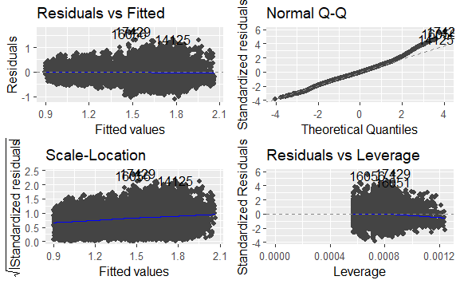

```r
autoplot(model3c)
```

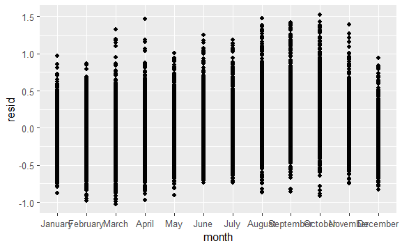

```r
price_resid_2 %>%
  ggplot(aes(x = month, y = resid))+
  geom_point()
```

```
 Missing rows: 9213, 11025, 11321, 11322, 11334, 11348, 11349, 11388, 11389, 11595, 11596, 11597, 11598, 11615, 11663
```

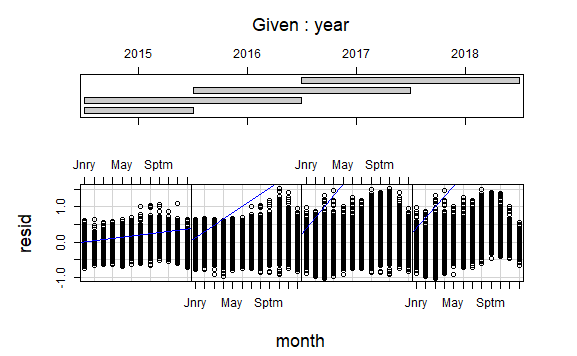

```r
coplot(resid ~ month | year,
       panel = function(x,y, ...){
         points(x,y)
         abline(lm(y ~x), col = "blue")
       },
       data = price_resid_2, rows = 1)
```

```r
model3c2 <- lm(average_price ~ type + ratio_large_sold + month:year, avocados_tidy_no_region)
summary(model3c2)
```

```
Call:
lm(formula = average_price ~ type + ratio_large_sold + month:year,
    data = avocados_tidy_no_region)

Residuals:
     Min       1Q   Median       3Q      Max
-1.09821 -0.17884 -0.01578  0.17000  1.60587

Coefficients:
                      Estimate Std. Error t value Pr(>|t|)
(Intercept)         -1.664e+02  4.660e+00  -35.70   <2e-16
typeorganic          5.177e-01  4.153e-03  124.67   <2e-16
ratio_large_sold     4.435e-01  9.045e-03   49.03   <2e-16
monthJanuary:year    8.294e-02  2.310e-03   35.90   <2e-16
monthFebruary:year   8.293e-02  2.310e-03   35.89   <2e-16
monthMarch:year      8.296e-02  2.311e-03   35.91   <2e-16
monthApril:year      8.299e-02  2.311e-03   35.91   <2e-16
monthMay:year        8.298e-02  2.311e-03   35.91   <2e-16
monthJune:year       8.301e-02  2.311e-03   35.92   <2e-16
monthJuly:year       8.303e-02  2.311e-03   35.93   <2e-16
monthAugust:year     8.306e-02  2.311e-03   35.94   <2e-16
monthSeptember:year  8.309e-02  2.311e-03   35.95   <2e-16
monthOctober:year    8.309e-02  2.311e-03   35.96   <2e-16
monthNovember:year   8.304e-02  2.311e-03   35.93   <2e-16
monthDecember:year   8.297e-02  2.311e-03   35.91   <2e-16

(Intercept)         ***
typeorganic         ***
ratio_large_sold    ***
monthJanuary:year   ***
monthFebruary:year  ***
monthMarch:year     ***
monthApril:year     ***
monthMay:year       ***
monthJune:year      ***
monthJuly:year      ***
monthAugust:year    ***
monthSeptember:year ***
monthOctober:year   ***
monthNovember:year  ***
monthDecember:year  ***
---
Signif. codes:  0 ‘***’ 0.001 ‘**’ 0.01 ‘*’ 0.05 ‘.’ 0.1 ‘ ’ 1

Residual standard error: 0.2789 on 18234 degrees of freedom
Multiple R-squared:  0.5207,    Adjusted R-squared:  0.5203
F-statistic:  1415 on 14 and 18234 DF,  p-value: < 2.2e-16
```

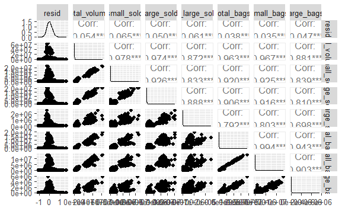

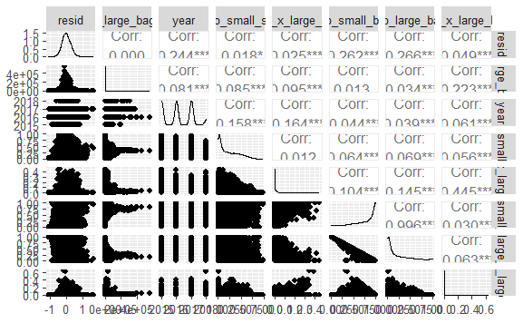

```r
price_resid_3 %>%
  select(resid, x_large_bags:ratio_x_large_bags) %>%
  ggpairs()
```

# 4th round of modeling

```r
model4a <- lm(average_price ~ type + ratio_large_sold + month + ratio_large_bags, avocados_tidy_no_region)
summary(model4a)
```

```
Call:
lm(formula = average_price ~ type + ratio_large_sold + month +
    ratio_large_bags, data = avocados_tidy_no_region)

Residuals:
     Min       1Q   Median       3Q      Max
-0.96760 -0.18519 -0.02104  0.16468  1.60814

Coefficients:
                  Estimate Std. Error t value Pr(>|t|)
(Intercept)       1.038328   0.008527 121.770  < 2e-16 ***
typeorganic       0.535525   0.004179 128.150  < 2e-16 ***
ratio_large_sold  0.389167   0.008835  44.046  < 2e-16 ***
monthAugust       0.124437   0.010501  11.850  < 2e-16 ***
monthDecember    -0.036178   0.010500  -3.445 0.000571 ***
monthFebruary    -0.097252   0.009994  -9.731  < 2e-16 ***
monthJanuary     -0.063255   0.009740  -6.494 8.55e-11 ***
monthJuly         0.083619   0.010313   8.108 5.48e-16 ***
monthJune         0.033987   0.010724   3.169 0.001531 **
monthMarch       -0.039724   0.009862  -4.028 5.65e-05 ***
monthMay         -0.025863   0.010308  -2.509 0.012115 *
monthNovember     0.085197   0.010496   8.117 5.07e-16 ***
monthOctober      0.203689   0.010310  19.757  < 2e-16 ***
monthSeptember    0.193708   0.010712  18.083  < 2e-16 ***
ratio_large_bags -0.274403   0.007291 -37.635  < 2e-16 ***
---
Signif. codes:  0 ‘***’ 0.001 ‘**’ 0.01 ‘*’ 0.05 ‘.’ 0.1 ‘ ’ 1

Residual standard error: 0.278 on 18219 degrees of freedom
  (15 observations deleted due to missingness)
Multiple R-squared:  0.5233,    Adjusted R-squared:  0.5229
F-statistic:  1428 on 14 and 18219 DF,  p-value: < 2.2e-16
```

```r
model4b <- lm(average_price ~ type + ratio_large_sold + month + ratio_small_bags, avocados_tidy_no_region)
summary(model4b)
```

```
Call:
lm(formula = average_price ~ type + ratio_large_sold + month +
    ratio_small_bags, data = avocados_tidy_no_region)

Residuals:
     Min       1Q   Median       3Q      Max
-0.96533 -0.18572 -0.02148  0.16488  1.60984

Coefficients:
                  Estimate Std. Error t value Pr(>|t|)
(Intercept)       0.771902   0.010195  75.713  < 2e-16 ***
typeorganic       0.531044   0.004171 127.306  < 2e-16 ***
ratio_large_sold  0.388706   0.008848  43.931  < 2e-16 ***
monthAugust       0.126092   0.010515  11.991  < 2e-16 ***
monthDecember    -0.035720   0.010515  -3.397 0.000683 ***
monthFebruary    -0.096783   0.010009  -9.670  < 2e-16 ***
monthJanuary     -0.063104   0.009754  -6.470 1.01e-10 ***
monthJuly         0.086690   0.010328   8.394  < 2e-16 ***
monthJune         0.036314   0.010740   3.381 0.000723 ***
monthMarch       -0.039284   0.009876  -3.978 6.99e-05 ***
monthMay         -0.025588   0.010323  -2.479 0.013194 *
monthNovember     0.084916   0.010511   8.079 6.96e-16 ***
monthOctober      0.203562   0.010325  19.716  < 2e-16 ***
monthSeptember    0.194341   0.010728  18.116  < 2e-16 ***
ratio_small_bags  0.268761   0.007289  36.872  < 2e-16 ***
---
Signif. codes:  0 ‘***’ 0.001 ‘**’ 0.01 ‘*’ 0.05 ‘.’ 0.1 ‘ ’ 1

Residual standard error: 0.2784 on 18219 degrees of freedom
  (15 observations deleted due to missingness)
Multiple R-squared:  0.5219,    Adjusted R-squared:  0.5215
F-statistic:  1420 on 14 and 18219 DF,  p-value: < 2.2e-16
```

```r
model4c <- lm(average_price ~ type + ratio_large_sold + month + year, avocados_tidy_no_region)
summary(model4c)
```

```
Call:
lm(formula = average_price ~ type + ratio_large_sold + month +
    year, data = avocados_tidy_no_region)

Residuals:
    Min      1Q  Median      3Q     Max
-1.0982 -0.1788 -0.0158  0.1700  1.6059

Coefficients:
                   Estimate Std. Error t value Pr(>|t|)
(Intercept)      -1.663e+02  4.660e+00 -35.700  < 2e-16 ***
typeorganic       5.177e-01  4.153e-03 124.666  < 2e-16 ***
ratio_large_sold  4.435e-01  9.045e-03  49.030  < 2e-16 ***
monthAugust       1.510e-01  1.053e-02  14.333  < 2e-16 ***
monthDecember    -3.039e-02  1.053e-02  -2.886 0.003912 **
monthFebruary    -1.269e-01  1.007e-02 -12.610  < 2e-16 ***
monthJanuary     -9.528e-02  9.816e-03  -9.707  < 2e-16 ***
monthJuly         8.977e-02  1.034e-02   8.684  < 2e-16 ***
monthJune         4.137e-02  1.075e-02   3.849 0.000119 ***
monthMarch       -6.157e-02  9.917e-03  -6.208 5.47e-10 ***
monthMay         -1.716e-02  1.034e-02  -1.659 0.097103 .
monthNovember     1.009e-01  1.053e-02   9.581  < 2e-16 ***
monthOctober      2.081e-01  1.034e-02  20.127  < 2e-16 ***
monthSeptember    2.061e-01  1.074e-02  19.182  < 2e-16 ***
year              8.299e-02  2.311e-03  35.911  < 2e-16 ***
---
Signif. codes:  0 ‘***’ 0.001 ‘**’ 0.01 ‘*’ 0.05 ‘.’ 0.1 ‘ ’ 1

Residual standard error: 0.2789 on 18234 degrees of freedom
Multiple R-squared:  0.5206,    Adjusted R-squared:  0.5203
F-statistic:  1415 on 14 and 18234 DF,  p-value: < 2.2e-16
```

```r
model4d <- lm(average_price ~ type + ratio_large_sold + month + small_sold, avocados_tidy_no_region)
summary(model4d)
```

```
Call:
lm(formula = average_price ~ type + ratio_large_sold + month +
    small_sold, data = avocados_tidy_no_region)

Residuals:
     Min       1Q   Median       3Q      Max
-1.11034 -0.18889 -0.01418  0.17697  1.65931

Coefficients:
                   Estimate Std. Error t value Pr(>|t|)
(Intercept)       9.956e-01  8.799e-03 113.145  < 2e-16 ***
typeorganic       5.051e-01  4.408e-03 114.570  < 2e-16 ***
ratio_large_sold  3.687e-01  9.162e-03  40.245  < 2e-16 ***
monthAugust       1.378e-01  1.087e-02  12.680  < 2e-16 ***
monthDecember    -3.349e-02  1.087e-02  -3.080  0.00207 **
monthFebruary    -9.255e-02  1.035e-02  -8.944  < 2e-16 ***
monthJanuary     -6.099e-02  1.009e-02  -6.047 1.50e-09 ***
monthJuly         8.869e-02  1.067e-02   8.310  < 2e-16 ***
monthJune         3.522e-02  1.110e-02   3.174  0.00151 **
monthMarch       -3.533e-02  1.021e-02  -3.461  0.00054 ***
monthMay         -2.863e-02  1.067e-02  -2.683  0.00731 **
monthNovember     8.565e-02  1.087e-02   7.880 3.47e-15 ***
monthOctober      2.057e-01  1.067e-02  19.267  < 2e-16 ***
monthSeptember    1.986e-01  1.109e-02  17.904  < 2e-16 ***
small_sold       -1.574e-08  1.737e-09  -9.065  < 2e-16 ***
---
Signif. codes:  0 ‘***’ 0.001 ‘**’ 0.01 ‘*’ 0.05 ‘.’ 0.1 ‘ ’ 1

Residual standard error: 0.288 on 18234 degrees of freedom
Multiple R-squared:  0.489, Adjusted R-squared:  0.4886
F-statistic:  1246 on 14 and 18234 DF,  p-value: < 2.2e-16
```

Adding ratio_large_bags proved most effective which helps for simlicity as the amount of large_sold is already in the model

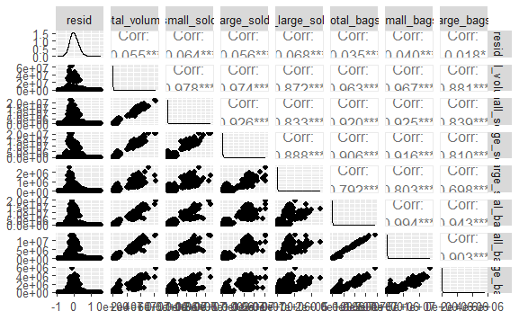

```r
price_resid_4 <- avocados_tidy_no_region %>%
  add_residuals(model4a) %>%
  add_predictions(model4a) %>%
  select(-average_price, -type, - ratio_large_sold, -month, -ratio_large_sold)

price_resid_4 %>%
  select(resid, total_volume:large_bags) %>%
  ggpairs()
```

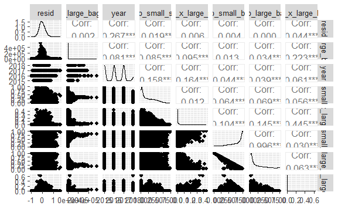

```r
price_resid_4 %>%
  select(resid, x_large_bags:ratio_x_large_bags) %>%
  ggpairs()
```

# 5th round of modeling

```r
model5a <- lm(average_price ~ type + ratio_large_sold + month + ratio_large_bags + year, avocados_tidy_no_region)
summary(model5a)
```

```
Call:
lm(formula = average_price ~ type + ratio_large_sold + month +
    ratio_large_bags + year, data = avocados_tidy_no_region)

Residuals:
     Min       1Q   Median       3Q      Max
-0.94166 -0.17574 -0.02002  0.16082  1.54639

Coefficients:
                   Estimate Std. Error t value Pr(>|t|)
(Intercept)      -1.758e+02  4.463e+00 -39.388  < 2e-16 ***
typeorganic       5.400e-01  4.011e-03 134.622  < 2e-16 ***
ratio_large_sold  4.614e-01  8.672e-03  53.210  < 2e-16 ***
monthAugust       1.374e-01  1.008e-02  13.626  < 2e-16 ***
monthDecember    -3.424e-02  1.008e-02  -3.399 0.000678 ***
monthFebruary    -1.332e-01  9.633e-03 -13.826  < 2e-16 ***
monthJanuary     -9.984e-02  9.391e-03 -10.631  < 2e-16 ***
monthJuly         8.408e-02  9.896e-03   8.496  < 2e-16 ***
monthJune         4.075e-02  1.029e-02   3.959 7.55e-05 ***
monthMarch       -6.789e-02  9.490e-03  -7.154 8.72e-13 ***
monthMay         -1.284e-02  9.896e-03  -1.298 0.194409
monthNovember     9.986e-02  1.008e-02   9.909  < 2e-16 ***
monthOctober      2.045e-01  9.892e-03  20.670  < 2e-16 ***
monthSeptember    2.005e-01  1.028e-02  19.507  < 2e-16 ***
ratio_large_bags -2.884e-01  7.005e-03 -41.175  < 2e-16 ***
year              8.770e-02  2.213e-03  39.621  < 2e-16 ***
---
Signif. codes:  0 ‘***’ 0.001 ‘**’ 0.01 ‘*’ 0.05 ‘.’ 0.1 ‘ ’ 1

Residual standard error: 0.2667 on 18218 degrees of freedom
  (15 observations deleted due to missingness)
Multiple R-squared:  0.5611,    Adjusted R-squared:  0.5607
F-statistic:  1553 on 15 and 18218 DF,  p-value: < 2.2e-16
```

```r
model5b <- lm(average_price ~ type + ratio_large_sold + month + ratio_large_bags + large_sold, avocados_tidy_no_region)
summary(model5b)
```

```
Call:
lm(formula = average_price ~ type + ratio_large_sold + month +
    ratio_large_bags + large_sold, data = avocados_tidy_no_region)

Residuals:
     Min       1Q   Median       3Q      Max
-0.96637 -0.18450 -0.02009  0.16445  1.60882

Coefficients:
                   Estimate Std. Error t value Pr(>|t|)
(Intercept)       1.045e+00  8.557e-03 122.135  < 2e-16 ***
typeorganic       5.281e-01  4.279e-03 123.406  < 2e-16 ***
ratio_large_sold  3.926e-01  8.832e-03  44.451  < 2e-16 ***
monthAugust       1.243e-01  1.048e-02  11.853  < 2e-16 ***
monthDecember    -3.640e-02  1.048e-02  -3.473 0.000517 ***
monthFebruary    -9.642e-02  9.979e-03  -9.663  < 2e-16 ***
monthJanuary     -6.274e-02  9.724e-03  -6.452 1.13e-10 ***
monthJuly         8.366e-02  1.030e-02   8.125 4.75e-16 ***
monthJune         3.412e-02  1.071e-02   3.187 0.001439 **
monthMarch       -3.964e-02  9.846e-03  -4.026 5.70e-05 ***
monthMay         -2.525e-02  1.029e-02  -2.453 0.014175 *
monthNovember     8.455e-02  1.048e-02   8.068 7.58e-16 ***
monthOctober      2.031e-01  1.029e-02  19.737  < 2e-16 ***
monthSeptember    1.935e-01  1.069e-02  18.091  < 2e-16 ***
ratio_large_bags -2.753e-01  7.280e-03 -37.820  < 2e-16 ***
large_sold       -1.372e-08  1.757e-09  -7.810 6.02e-15 ***
---
Signif. codes:  0 ‘***’ 0.001 ‘**’ 0.01 ‘*’ 0.05 ‘.’ 0.1 ‘ ’ 1

Residual standard error: 0.2775 on 18218 degrees of freedom
  (15 observations deleted due to missingness)
Multiple R-squared:  0.5248,    Adjusted R-squared:  0.5245
F-statistic:  1342 on 15 and 18218 DF,  p-value: < 2.2e-16
```

```r
model5c <- lm(average_price ~ type + ratio_large_sold + month + ratio_large_bags + x_large_sold, avocados_tidy_no_region)
summary(model5c)
```

```
Call:
lm(formula = average_price ~ type + ratio_large_sold + month +
    ratio_large_bags + x_large_sold, data = avocados_tidy_no_region)

Residuals:
    Min      1Q  Median      3Q     Max
-0.9669 -0.1836 -0.0204  0.1638  1.6073

Coefficients:
                   Estimate Std. Error t value Pr(>|t|)
(Intercept)       1.048e+00  8.561e-03 122.357  < 2e-16 ***
typeorganic       5.273e-01  4.259e-03 123.797  < 2e-16 ***
ratio_large_sold  3.894e-01  8.814e-03  44.177  < 2e-16 ***
monthAugust       1.232e-01  1.048e-02  11.761  < 2e-16 ***
monthDecember    -3.783e-02  1.048e-02  -3.611 0.000306 ***
monthFebruary    -9.681e-02  9.970e-03  -9.709  < 2e-16 ***
monthJanuary     -6.372e-02  9.716e-03  -6.558 5.61e-11 ***
monthJuly         8.334e-02  1.029e-02   8.101 5.81e-16 ***
monthJune         3.454e-02  1.070e-02   3.229 0.001245 **
monthMarch       -3.992e-02  9.838e-03  -4.057 4.98e-05 ***
monthMay         -2.539e-02  1.028e-02  -2.469 0.013558 *
monthNovember     8.335e-02  1.047e-02   7.959 1.84e-15 ***
monthOctober      2.021e-01  1.029e-02  19.644  < 2e-16 ***
monthSeptember    1.921e-01  1.069e-02  17.975  < 2e-16 ***
ratio_large_bags -2.756e-01  7.275e-03 -37.885  < 2e-16 ***
x_large_sold     -1.855e-07  1.956e-08  -9.484  < 2e-16 ***
---
Signif. codes:  0 ‘***’ 0.001 ‘**’ 0.01 ‘*’ 0.05 ‘.’ 0.1 ‘ ’ 1

Residual standard error: 0.2773 on 18218 degrees of freedom
  (15 observations deleted due to missingness)
Multiple R-squared:  0.5256,    Adjusted R-squared:  0.5252
F-statistic:  1346 on 15 and 18218 DF,  p-value: < 2.2e-16
```

```r
model5d <- lm(average_price ~ type + ratio_large_sold + month + ratio_large_bags + small_sold, avocados_tidy_no_region)
summary(model5d)
```

```
Call:
lm(formula = average_price ~ type + ratio_large_sold + month +
    ratio_large_bags + small_sold, data = avocados_tidy_no_region)

Residuals:
     Min       1Q   Median       3Q      Max
-0.96818 -0.18427 -0.02076  0.16457  1.60596

Coefficients:
                   Estimate Std. Error t value Pr(>|t|)
(Intercept)       1.050e+00  8.601e-03 122.020  < 2e-16 ***
typeorganic       5.266e-01  4.288e-03 122.815  < 2e-16 ***
ratio_large_sold  3.827e-01  8.846e-03  43.264  < 2e-16 ***
monthAugust       1.241e-01  1.048e-02  11.845  < 2e-16 ***
monthDecember    -3.731e-02  1.048e-02  -3.561 0.000371 ***
monthFebruary    -9.673e-02  9.973e-03  -9.699  < 2e-16 ***
monthJanuary     -6.356e-02  9.719e-03  -6.539 6.35e-11 ***
monthJuly         8.327e-02  1.029e-02   8.091 6.27e-16 ***
monthJune         3.431e-02  1.070e-02   3.206 0.001347 **
monthMarch       -3.997e-02  9.841e-03  -4.062 4.90e-05 ***
monthMay         -2.533e-02  1.029e-02  -2.462 0.013817 *
monthNovember     8.384e-02  1.047e-02   8.004 1.27e-15 ***
monthOctober      2.022e-01  1.029e-02  19.651  < 2e-16 ***
monthSeptember    1.929e-01  1.069e-02  18.042  < 2e-16 ***
ratio_large_bags -2.735e-01  7.276e-03 -37.588  < 2e-16 ***
small_sold       -1.489e-08  1.673e-09  -8.899  < 2e-16 ***
---
Signif. codes:  0 ‘***’ 0.001 ‘**’ 0.01 ‘*’ 0.05 ‘.’ 0.1 ‘ ’ 1

Residual standard error: 0.2774 on 18218 degrees of freedom
  (15 observations deleted due to missingness)
Multiple R-squared:  0.5253,    Adjusted R-squared:  0.5249
F-statistic:  1344 on 15 and 18218 DF,  p-value: < 2.2e-16
```

```r
model5e <- lm(average_price ~ type + ratio_large_sold + month + ratio_large_bags + total_volume, avocados_tidy_no_region)
summary(model5e)
```

```
Call:
lm(formula = average_price ~ type + ratio_large_sold + month +
    ratio_large_bags + total_volume, data = avocados_tidy_no_region)

Residuals:
     Min       1Q   Median       3Q      Max
-0.96734 -0.18471 -0.02043  0.16490  1.60731

Coefficients:
                   Estimate Std. Error t value Pr(>|t|)
(Intercept)       1.047e+00  8.586e-03 121.927  < 2e-16 ***
typeorganic       5.279e-01  4.290e-03 123.067  < 2e-16 ***
ratio_large_sold  3.874e-01  8.824e-03  43.902  < 2e-16 ***
monthAugust       1.241e-01  1.048e-02  11.835  < 2e-16 ***
monthDecember    -3.672e-02  1.048e-02  -3.503 0.000462 ***
monthFebruary    -9.663e-02  9.979e-03  -9.683  < 2e-16 ***
monthJanuary     -6.316e-02  9.724e-03  -6.495 8.54e-11 ***
monthJuly         8.352e-02  1.030e-02   8.111 5.35e-16 ***
monthJune         3.421e-02  1.071e-02   3.195 0.001400 **
monthMarch       -3.973e-02  9.846e-03  -4.035 5.48e-05 ***
monthMay         -2.543e-02  1.029e-02  -2.470 0.013502 *
monthNovember     8.423e-02  1.048e-02   8.037 9.75e-16 ***
monthOctober      2.027e-01  1.029e-02  19.695  < 2e-16 ***
monthSeptember    1.931e-01  1.070e-02  18.055  < 2e-16 ***
ratio_large_bags -2.742e-01  7.280e-03 -37.665  < 2e-16 ***
total_volume     -4.685e-09  6.121e-10  -7.653 2.06e-14 ***
---
Signif. codes:  0 ‘***’ 0.001 ‘**’ 0.01 ‘*’ 0.05 ‘.’ 0.1 ‘ ’ 1

Residual standard error: 0.2775 on 18218 degrees of freedom
  (15 observations deleted due to missingness)
Multiple R-squared:  0.5248,    Adjusted R-squared:  0.5244
F-statistic:  1341 on 15 and 18218 DF,  p-value: < 2.2e-16
```

year is the best addition

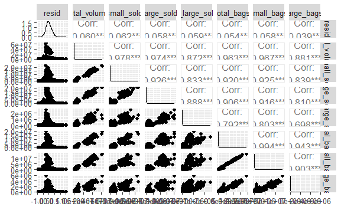

```r
price_resid_5 <- avocados_tidy_no_region %>%
  add_residuals(model5a) %>%
  add_predictions(model5a) %>%
  select(-average_price, -type, - ratio_large_sold, -month, -ratio_large_sold, -year)

price_resid_5 %>%
  select(resid, total_volume:large_bags) %>%
  ggpairs()
```

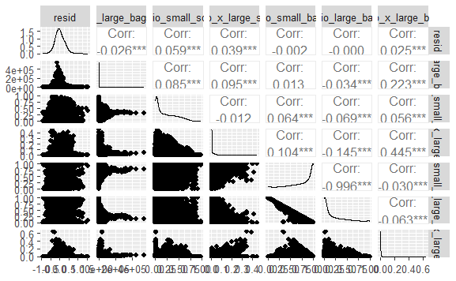

```r
price_resid_5 %>%
  select(resid, x_large_bags:ratio_x_large_bags) %>%
  ggpairs()
```

# 6th round of modeling

```r
model6a <- lm(average_price ~ type + ratio_large_sold + month + ratio_large_bags + year + total_volume, avocados_tidy_no_region)
summary(model6a)
```

```
Call:
lm(formula = average_price ~ type + ratio_large_sold + month +
    ratio_large_bags + year + total_volume, data = avocados_tidy_no_region)

Residuals:
     Min       1Q   Median       3Q      Max
-0.94133 -0.17538 -0.01848  0.16094  1.54540

Coefficients:
                   Estimate Std. Error t value Pr(>|t|)
(Intercept)      -1.761e+02  4.455e+00 -39.534  < 2e-16 ***
typeorganic       5.321e-01  4.116e-03 129.264  < 2e-16 ***
ratio_large_sold  4.597e-01  8.658e-03  53.100  < 2e-16 ***
monthAugust       1.370e-01  1.006e-02  13.618  < 2e-16 ***
monthDecember    -3.481e-02  1.006e-02  -3.461 0.000539 ***
monthFebruary    -1.326e-01  9.615e-03 -13.791  < 2e-16 ***
monthJanuary     -9.980e-02  9.374e-03 -10.647  < 2e-16 ***
monthJuly         8.397e-02  9.878e-03   8.501  < 2e-16 ***
monthJune         4.099e-02  1.027e-02   3.991 6.61e-05 ***
monthMarch       -6.796e-02  9.472e-03  -7.175 7.53e-13 ***
monthMay         -1.236e-02  9.878e-03  -1.251 0.210826
monthNovember     9.888e-02  1.006e-02   9.829  < 2e-16 ***
monthOctober      2.035e-01  9.875e-03  20.607  < 2e-16 ***
monthSeptember    1.999e-01  1.026e-02  19.483  < 2e-16 ***
ratio_large_bags -2.883e-01  6.992e-03 -41.225  < 2e-16 ***
year              8.787e-02  2.209e-03  39.770  < 2e-16 ***
total_volume     -4.897e-09  5.872e-10  -8.339  < 2e-16 ***
---
Signif. codes:  0 ‘***’ 0.001 ‘**’ 0.01 ‘*’ 0.05 ‘.’ 0.1 ‘ ’ 1

Residual standard error: 0.2662 on 18217 degrees of freedom
  (15 observations deleted due to missingness)
Multiple R-squared:  0.5627,    Adjusted R-squared:  0.5624
F-statistic:  1465 on 16 and 18217 DF,  p-value: < 2.2e-16
```

```r
model6b <- lm(average_price ~ type + ratio_large_sold + month + ratio_large_bags + year + small_sold, avocados_tidy_no_region)
summary(model6b)
```

```
Call:
lm(formula = average_price ~ type + ratio_large_sold + month +
    ratio_large_bags + year + small_sold, data = avocados_tidy_no_region)

Residuals:
     Min       1Q   Median       3Q      Max
-0.94229 -0.17554 -0.01917  0.16092  1.54460

Coefficients:
                   Estimate Std. Error t value Pr(>|t|)
(Intercept)      -1.751e+02  4.455e+00 -39.309  < 2e-16 ***
typeorganic       5.318e-01  4.117e-03 129.159  < 2e-16 ***
ratio_large_sold  4.552e-01  8.685e-03  52.410  < 2e-16 ***
monthAugust       1.370e-01  1.006e-02  13.620  < 2e-16 ***
monthDecember    -3.530e-02  1.006e-02  -3.510 0.000448 ***
monthFebruary    -1.326e-01  9.614e-03 -13.789  < 2e-16 ***
monthJanuary     -9.998e-02  9.373e-03 -10.667  < 2e-16 ***
monthJuly         8.376e-02  9.876e-03   8.480  < 2e-16 ***
monthJune         4.102e-02  1.027e-02   3.994 6.53e-05 ***
monthMarch       -6.801e-02  9.471e-03  -7.181 7.16e-13 ***
monthMay         -1.240e-02  9.877e-03  -1.255 0.209509
monthNovember     9.855e-02  1.006e-02   9.797  < 2e-16 ***
monthOctober      2.031e-01  9.874e-03  20.567  < 2e-16 ***
monthSeptember    1.997e-01  1.026e-02  19.466  < 2e-16 ***
ratio_large_bags -2.876e-01  6.992e-03 -41.126  < 2e-16 ***
year              8.737e-02  2.209e-03  39.544  < 2e-16 ***
small_sold       -1.378e-08  1.606e-09  -8.583  < 2e-16 ***
---
Signif. codes:  0 ‘***’ 0.001 ‘**’ 0.01 ‘*’ 0.05 ‘.’ 0.1 ‘ ’ 1

Residual standard error: 0.2662 on 18217 degrees of freedom
  (15 observations deleted due to missingness)
Multiple R-squared:  0.5628,    Adjusted R-squared:  0.5625
F-statistic:  1466 on 16 and 18217 DF,  p-value: < 2.2e-16
```

```r
model6c <- lm(average_price ~ type + ratio_large_sold + month + ratio_large_bags + year + large_sold, avocados_tidy_no_region)
summary(model6c)
```

```
Call:
lm(formula = average_price ~ type + ratio_large_sold + month +
    ratio_large_bags + year + large_sold, data = avocados_tidy_no_region)

Residuals:
     Min       1Q   Median       3Q      Max
-0.94046 -0.17537 -0.01839  0.16070  1.54709

Coefficients:
                   Estimate Std. Error t value Pr(>|t|)
(Intercept)      -1.757e+02  4.455e+00 -39.431  < 2e-16 ***
typeorganic       5.327e-01  4.107e-03 129.691  < 2e-16 ***
ratio_large_sold  4.648e-01  8.667e-03  53.625  < 2e-16 ***
monthAugust       1.372e-01  1.006e-02  13.632  < 2e-16 ***
monthDecember    -3.447e-02  1.006e-02  -3.427 0.000612 ***
monthFebruary    -1.323e-01  9.617e-03 -13.762  < 2e-16 ***
monthJanuary     -9.931e-02  9.375e-03 -10.592  < 2e-16 ***
monthJuly         8.412e-02  9.879e-03   8.515  < 2e-16 ***
monthJune         4.088e-02  1.027e-02   3.979 6.95e-05 ***
monthMarch       -6.779e-02  9.473e-03  -7.156 8.62e-13 ***
monthMay         -1.224e-02  9.880e-03  -1.239 0.215341
monthNovember     9.921e-02  1.006e-02   9.861  < 2e-16 ***
monthOctober      2.039e-01  9.876e-03  20.651  < 2e-16 ***
monthSeptember    2.003e-01  1.026e-02  19.518  < 2e-16 ***
ratio_large_bags -2.894e-01  6.994e-03 -41.372  < 2e-16 ***
year              8.765e-02  2.210e-03  39.666  < 2e-16 ***
large_sold       -1.353e-08  1.686e-09  -8.023 1.09e-15 ***
---
Signif. codes:  0 ‘***’ 0.001 ‘**’ 0.01 ‘*’ 0.05 ‘.’ 0.1 ‘ ’ 1

Residual standard error: 0.2663 on 18217 degrees of freedom
  (15 observations deleted due to missingness)
Multiple R-squared:  0.5626,    Adjusted R-squared:  0.5622
F-statistic:  1465 on 16 and 18217 DF,  p-value: < 2.2e-16
```

```r
model6d <- lm(average_price ~ type + ratio_large_sold + month + ratio_large_bags + year + x_large_sold, avocados_tidy_no_region)
summary(model6d)
```

```
Call:
lm(formula = average_price ~ type + ratio_large_sold + month +
    ratio_large_bags + year + x_large_sold, data = avocados_tidy_no_region)

Residuals:
     Min       1Q   Median       3Q      Max
-0.94127 -0.17489 -0.01876  0.16005  1.54626

Coefficients:
                   Estimate Std. Error t value Pr(>|t|)
(Intercept)      -1.742e+02  4.459e+00 -39.077  < 2e-16 ***
typeorganic       5.331e-01  4.092e-03 130.282  < 2e-16 ***
ratio_large_sold  4.610e-01  8.656e-03  53.253  < 2e-16 ***
monthAugust       1.362e-01  1.006e-02  13.537  < 2e-16 ***
monthDecember    -3.564e-02  1.006e-02  -3.543 0.000397 ***
monthFebruary    -1.325e-01  9.616e-03 -13.779  < 2e-16 ***
monthJanuary     -9.990e-02  9.374e-03 -10.657  < 2e-16 ***
monthJuly         8.385e-02  9.878e-03   8.488  < 2e-16 ***
monthJune         4.115e-02  1.027e-02   4.006 6.21e-05 ***
monthMarch       -6.781e-02  9.472e-03  -7.158 8.47e-13 ***
monthMay         -1.256e-02  9.879e-03  -1.272 0.203522
monthNovember     9.819e-02  1.006e-02   9.759  < 2e-16 ***
monthOctober      2.031e-01  9.876e-03  20.567  < 2e-16 ***
monthSeptember    1.991e-01  1.026e-02  19.404  < 2e-16 ***
ratio_large_bags -2.893e-01  6.993e-03 -41.370  < 2e-16 ***
year              8.693e-02  2.211e-03  39.312  < 2e-16 ***
x_large_sold     -1.544e-07  1.880e-08  -8.212 2.32e-16 ***
---
Signif. codes:  0 ‘***’ 0.001 ‘**’ 0.01 ‘*’ 0.05 ‘.’ 0.1 ‘ ’ 1

Residual standard error: 0.2662 on 18217 degrees of freedom
  (15 observations deleted due to missingness)
Multiple R-squared:  0.5627,    Adjusted R-squared:  0.5623
F-statistic:  1465 on 16 and 18217 DF,  p-value: < 2.2e-16
```

```r
model6e <- lm(average_price ~ type + ratio_large_sold + month + ratio_large_bags + year + small_bags, avocados_tidy_no_region)
summary(model6e)
```

```
Call:
lm(formula = average_price ~ type + ratio_large_sold + month +
    ratio_large_bags + year + small_bags, data = avocados_tidy_no_region)

Residuals:
     Min       1Q   Median       3Q      Max
-0.94136 -0.17548 -0.01881  0.16099  1.54421

Coefficients:
                   Estimate Std. Error t value Pr(>|t|)
(Intercept)      -1.779e+02  4.463e+00 -39.855  < 2e-16 ***
typeorganic       5.328e-01  4.103e-03 129.841  < 2e-16 ***
ratio_large_sold  4.597e-01  8.659e-03  53.090  < 2e-16 ***
monthAugust       1.370e-01  1.006e-02  13.610  < 2e-16 ***
monthDecember    -3.458e-02  1.006e-02  -3.438 0.000587 ***
monthFebruary    -1.332e-01  9.616e-03 -13.847  < 2e-16 ***
monthJanuary     -1.003e-01  9.375e-03 -10.695  < 2e-16 ***
monthJuly         8.414e-02  9.879e-03   8.517  < 2e-16 ***
monthJune         4.110e-02  1.027e-02   4.001 6.34e-05 ***
monthMarch       -6.803e-02  9.473e-03  -7.181 7.17e-13 ***
monthMay         -1.259e-02  9.879e-03  -1.274 0.202588
monthNovember     9.896e-02  1.006e-02   9.836  < 2e-16 ***
monthOctober      2.035e-01  9.876e-03  20.606  < 2e-16 ***
monthSeptember    1.998e-01  1.026e-02  19.469  < 2e-16 ***
ratio_large_bags -2.894e-01  6.994e-03 -41.375  < 2e-16 ***
year              8.872e-02  2.213e-03  40.089  < 2e-16 ***
small_bags       -2.196e-08  2.716e-09  -8.085 6.61e-16 ***
---
Signif. codes:  0 ‘***’ 0.001 ‘**’ 0.01 ‘*’ 0.05 ‘.’ 0.1 ‘ ’ 1

Residual standard error: 0.2662 on 18217 degrees of freedom
  (15 observations deleted due to missingness)
Multiple R-squared:  0.5626,    Adjusted R-squared:  0.5623
F-statistic:  1465 on 16 and 18217 DF,  p-value: < 2.2e-16
```

For simplicity rather than taking the best variable to add (small_sold) will continue to add large advocado variable as there is a minimal difference in this addition 0.5628 Vs 0.5626. Would rather retain some simplicity in the model.

```r
summary(model6c)
```

```
Call:
lm(formula = average_price ~ type + ratio_large_sold + month +
    ratio_large_bags + year + large_sold, data = avocados_tidy_no_region)

Residuals:
     Min       1Q   Median       3Q      Max
-0.94046 -0.17537 -0.01839  0.16070  1.54709

Coefficients:
                   Estimate Std. Error t value Pr(>|t|)
(Intercept)      -1.756e+02  4.455e+00 -39.423  < 2e-16 ***
typeorganic       5.327e-01  4.107e-03 129.691  < 2e-16 ***
ratio_large_sold  4.648e-01  8.667e-03  53.625  < 2e-16 ***
month.L           2.589e-01  6.812e-03  38.007  < 2e-16 ***
month.Q          -1.775e-01  6.867e-03 -25.849  < 2e-16 ***
month.C          -1.730e-01  6.821e-03 -25.360  < 2e-16 ***
month^4          -6.277e-02  6.768e-03  -9.275  < 2e-16 ***
month^5          -2.788e-02  6.874e-03  -4.055 5.03e-05 ***
month^6           6.062e-02  6.954e-03   8.717  < 2e-16 ***
month^7          -4.001e-04  6.798e-03  -0.059  0.95307
month^8           1.267e-02  6.842e-03   1.852  0.06407 .
month^9           1.210e-02  7.027e-03   1.722  0.08502 .
month^10         -2.235e-02  7.059e-03  -3.167  0.00154 **
month^11          1.042e-02  7.096e-03   1.468  0.14212
ratio_large_bags -2.894e-01  6.994e-03 -41.372  < 2e-16 ***
year              8.765e-02  2.210e-03  39.666  < 2e-16 ***
large_sold       -1.353e-08  1.686e-09  -8.023 1.09e-15 ***
---
Signif. codes:  0 ‘***’ 0.001 ‘**’ 0.01 ‘*’ 0.05 ‘.’ 0.1 ‘ ’ 1

Residual standard error: 0.2663 on 18217 degrees of freedom
  (15 observations deleted due to missingness)
Multiple R-squared:  0.5626,    Adjusted R-squared:  0.5622
F-statistic:  1465 on 16 and 18217 DF,  p-value: < 2.2e-16
```

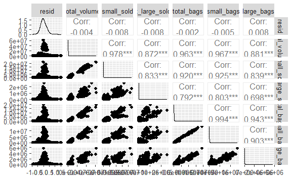

```r
price_resid_6 <- avocados_tidy_no_region %>%
  add_residuals(model6c) %>%
  add_predictions(model6c) %>%
  select(-average_price, -type, - ratio_large_sold, -month, -ratio_large_sold, -year, -large_sold)

price_resid_6 %>%
  select(resid, total_volume:large_bags) %>%
  ggpairs()
```

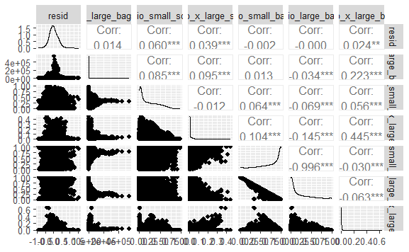

# 7th round of modeling

```r
model7a <- lm(average_price ~ type + ratio_large_sold + month + ratio_large_bags + year + large_sold + ratio_small_sold, avocados_tidy_no_region)
summary(model7a)
```

```
Call:
lm(formula = average_price ~ type + ratio_large_sold + month +
    ratio_large_bags + year + large_sold + ratio_small_sold,
    data = avocados_tidy_no_region)

Residuals:
     Min       1Q   Median       3Q      Max
-0.94607 -0.17522 -0.01769  0.15977  1.52467

Coefficients:
                   Estimate Std. Error t value Pr(>|t|)
(Intercept)      -1.933e+02  4.726e+00 -40.893  < 2e-16 ***
typeorganic       5.563e-01  4.633e-03 120.077  < 2e-16 ***
ratio_large_sold  5.327e-01  1.065e-02  50.010  < 2e-16 ***
month.L           2.674e-01  6.835e-03  39.122  < 2e-16 ***
month.Q          -1.759e-01  6.846e-03 -25.696  < 2e-16 ***
month.C          -1.725e-01  6.799e-03 -25.368  < 2e-16 ***
month^4          -6.293e-02  6.746e-03  -9.328  < 2e-16 ***
month^5          -2.827e-02  6.852e-03  -4.125 3.72e-05 ***
month^6           6.102e-02  6.931e-03   8.804  < 2e-16 ***
month^7          -7.501e-04  6.776e-03  -0.111   0.9119
month^8           1.314e-02  6.820e-03   1.926   0.0541 .
month^9           1.320e-02  7.005e-03   1.885   0.0595 .
month^10         -2.263e-02  7.036e-03  -3.216   0.0013 **
month^11          9.342e-03  7.074e-03   1.321   0.1866
ratio_large_bags -2.906e-01  6.972e-03 -41.684  < 2e-16 ***
year              9.636e-02  2.343e-03  41.126  < 2e-16 ***
large_sold       -1.387e-08  1.681e-09  -8.251  < 2e-16 ***
ratio_small_sold  1.343e-01  1.232e-02  10.901  < 2e-16 ***
---
Signif. codes:  0 ‘***’ 0.001 ‘**’ 0.01 ‘*’ 0.05 ‘.’ 0.1 ‘ ’ 1

Residual standard error: 0.2654 on 18216 degrees of freedom
  (15 observations deleted due to missingness)
Multiple R-squared:  0.5655,    Adjusted R-squared:  0.5651
F-statistic:  1394 on 17 and 18216 DF,  p-value: < 2.2e-16
```

```r
model7b <- lm(average_price ~ type + ratio_large_sold + month + ratio_large_bags + year + large_sold + ratio_x_large_bags, avocados_tidy_no_region)
summary(model7b)
```

```
Call:
lm(formula = average_price ~ type + ratio_large_sold + month +
    ratio_large_bags + year + large_sold + ratio_x_large_bags,
    data = avocados_tidy_no_region)

Residuals:
     Min       1Q   Median       3Q      Max
-0.94125 -0.17527 -0.01809  0.16142  1.54701

Coefficients:
                     Estimate Std. Error t value Pr(>|t|)
(Intercept)        -1.745e+02  4.467e+00 -39.062  < 2e-16 ***
typeorganic         5.367e-01  4.272e-03 125.635  < 2e-16 ***
ratio_large_sold    4.644e-01  8.665e-03  53.593  < 2e-16 ***
month.L             2.587e-01  6.811e-03  37.977  < 2e-16 ***
month.Q            -1.753e-01  6.894e-03 -25.429  < 2e-16 ***
month.C            -1.728e-01  6.819e-03 -25.344  < 2e-16 ***
month^4            -6.474e-02  6.790e-03  -9.534  < 2e-16 ***
month^5            -2.881e-02  6.877e-03  -4.189 2.81e-05 ***
month^6             6.182e-02  6.960e-03   8.881  < 2e-16 ***
month^7            -4.748e-05  6.797e-03  -0.007  0.99443
month^8             1.188e-02  6.844e-03   1.736  0.08265 .
month^9             1.206e-02  7.025e-03   1.717  0.08593 .
month^10           -2.183e-02  7.058e-03  -3.093  0.00198 **
month^11            1.050e-02  7.094e-03   1.480  0.13878
ratio_large_bags   -2.887e-01  6.995e-03 -41.267  < 2e-16 ***
year                8.707e-02  2.215e-03  39.303  < 2e-16 ***
large_sold         -1.341e-08  1.686e-09  -7.956 1.88e-15 ***
ratio_x_large_bags  2.701e-01  7.870e-02   3.432  0.00060 ***
---
Signif. codes:  0 ‘***’ 0.001 ‘**’ 0.01 ‘*’ 0.05 ‘.’ 0.1 ‘ ’ 1

Residual standard error: 0.2662 on 18216 degrees of freedom
  (15 observations deleted due to missingness)
Multiple R-squared:  0.5629,    Adjusted R-squared:  0.5625
F-statistic:  1380 on 17 and 18216 DF,  p-value: < 2.2e-16
```

```r
model7c <- lm(average_price ~ type + ratio_large_sold + month + ratio_large_bags + year + large_sold + ratio_x_large_sold, avocados_tidy_no_region)
summary(model7c)
```

```
Call:
lm(formula = average_price ~ type + ratio_large_sold + month +
    ratio_large_bags + year + large_sold + ratio_x_large_sold,
    data = avocados_tidy_no_region)

Residuals:
     Min       1Q   Median       3Q      Max
-0.93730 -0.17521 -0.01894  0.16081  1.54846

Coefficients:
                     Estimate Std. Error t value Pr(>|t|)
(Intercept)        -1.798e+02  4.512e+00 -39.837  < 2e-16 ***
typeorganic         5.381e-01  4.218e-03 127.590  < 2e-16 ***
ratio_large_sold    4.637e-01  8.662e-03  53.536  < 2e-16 ***
month.L             2.610e-01  6.817e-03  38.288  < 2e-16 ***
month.Q            -1.772e-01  6.861e-03 -25.827  < 2e-16 ***
month.C            -1.732e-01  6.815e-03 -25.415  < 2e-16 ***
month^4            -6.294e-02  6.763e-03  -9.306  < 2e-16 ***
month^5            -2.778e-02  6.868e-03  -4.045 5.26e-05 ***
month^6             6.111e-02  6.949e-03   8.795  < 2e-16 ***
month^7            -6.498e-04  6.793e-03  -0.096   0.9238
month^8             1.209e-02  6.837e-03   1.769   0.0769 .
month^9             1.221e-02  7.021e-03   1.739   0.0820 .
month^10           -2.239e-02  7.053e-03  -3.174   0.0015 **
month^11            1.055e-02  7.090e-03   1.488   0.1368
ratio_large_bags   -2.849e-01  7.034e-03 -40.502  < 2e-16 ***
year                8.968e-02  2.238e-03  40.078  < 2e-16 ***
large_sold         -1.346e-08  1.684e-09  -7.989 1.44e-15 ***
ratio_x_large_sold  2.775e-01  4.970e-02   5.584 2.38e-08 ***
---
Signif. codes:  0 ‘***’ 0.001 ‘**’ 0.01 ‘*’ 0.05 ‘.’ 0.1 ‘ ’ 1

Residual standard error: 0.266 on 18216 degrees of freedom
  (15 observations deleted due to missingness)
Multiple R-squared:  0.5634,    Adjusted R-squared:  0.563
F-statistic:  1383 on 17 and 18216 DF,  p-value: < 2.2e-16
```

```r
model7d <- lm(average_price ~ type + ratio_large_sold + month + ratio_large_bags + year + large_sold + x_large_bags, avocados_tidy_no_region)
summary(model7d)
```

```
Call:
lm(formula = average_price ~ type + ratio_large_sold + month +
    ratio_large_bags + year + large_sold + x_large_bags, data = avocados_tidy_no_region)

Residuals:
     Min       1Q   Median       3Q      Max
-0.94048 -0.17528 -0.01845  0.16063  1.54792

Coefficients:
                   Estimate Std. Error t value Pr(>|t|)
(Intercept)      -1.743e+02  4.483e+00 -38.878  < 2e-16 ***
typeorganic       5.330e-01  4.108e-03 129.736  < 2e-16 ***
ratio_large_sold  4.664e-01  8.688e-03  53.685  < 2e-16 ***
month.L           2.586e-01  6.812e-03  37.963  < 2e-16 ***
month.Q          -1.761e-01  6.886e-03 -25.574  < 2e-16 ***
month.C          -1.732e-01  6.820e-03 -25.391  < 2e-16 ***
month^4          -6.377e-02  6.778e-03  -9.409  < 2e-16 ***
month^5          -2.824e-02  6.874e-03  -4.108 4.01e-05 ***
month^6           6.133e-02  6.958e-03   8.815  < 2e-16 ***
month^7          -6.951e-05  6.798e-03  -0.010  0.99184
month^8           1.216e-02  6.843e-03   1.777  0.07565 .
month^9           1.198e-02  7.026e-03   1.705  0.08816 .
month^10         -2.207e-02  7.059e-03  -3.127  0.00177 **
month^11          1.053e-02  7.095e-03   1.484  0.13785
ratio_large_bags -2.893e-01  6.993e-03 -41.373  < 2e-16 ***
year              8.698e-02  2.223e-03  39.119  < 2e-16 ***
large_sold       -1.772e-08  2.311e-09  -7.668 1.84e-14 ***
x_large_bags      4.144e-07  1.562e-07   2.653  0.00799 **
---
Signif. codes:  0 ‘***’ 0.001 ‘**’ 0.01 ‘*’ 0.05 ‘.’ 0.1 ‘ ’ 1

Residual standard error: 0.2662 on 18216 degrees of freedom
  (15 observations deleted due to missingness)
Multiple R-squared:  0.5628,    Adjusted R-squared:  0.5624
F-statistic:  1379 on 17 and 18216 DF,  p-value: < 2.2e-16
```

```r
broom::glance(model1a)
```

| r.squared | adj.r.squared | sigma | statistic | p.value | df | logLik | AIC | BIC | deviance | df.residual | nobs |
| --- | --- | --- | --- | --- | --- | --- | --- | --- | --- | --- | --- |
| 0.3792649 | 0.3792309 | 0.3172644 | 11148.79 | 0 | 1 | -4942.998 | 9891.996 | 9915.432 | 1836.683 | 18247 | 18249 |

```r
broom::glance(model2a)
```

| r.squared | adj.r.squared | sigma | statistic | p.value | df | logLik | AIC | BIC | deviance | df.residual | nobs |
| --- | --- | --- | --- | --- | --- | --- | --- | --- | --- | --- | --- |
| 0.4139757 | 0.4139114 | 0.3080804 | 6439.316 | 0 | 2 | -4402.811 | 8813.622 | 8844.866 | 1730.368 | 18231 | 18234 |

```r
broom::glance(model3c)
```

| r.squared | adj.r.squared | sigma | statistic | p.value | df | logLik | AIC | BIC | deviance | df.residual | nobs |
| --- | --- | --- | --- | --- | --- | --- | --- | --- | --- | --- | --- |
| 0.4867247 | 0.4863588 | 0.2885933 | 1330.134 | 0 | 13 | -3208.503 | 6447.006 | 6564.184 | 1518.722 | 18235 | 18249 |

```r
broom::glance(model4a)
```

| r.squared | adj.r.squared | sigma | statistic | p.value | df | logLik | AIC | BIC | deviance | df.residual | nobs |
| --- | --- | --- | --- | --- | --- | --- | --- | --- | --- | --- | --- |
| 0.5232579 | 0.5228915 | 0.2779655 | 1428.331 | 0 | 14 | -2521.194 | 5074.389 | 5199.366 | 1407.688 | 18219 | 18234 |

```r
broom::glance(model5a)
```

| r.squared | adj.r.squared | sigma | statistic | p.value | df | logLik | AIC | BIC | deviance | df.residual | nobs |
| --- | --- | --- | --- | --- | --- | --- | --- | --- | --- | --- | --- |
| 0.5610791 | 0.5607177 | 0.2667192 | 1552.556 | 0 | 15 | -1767.615 | 3569.23 | 3702.018 | 1296.012 | 18218 | 18234 |

```r
broom::glance(model6c)
```

| r.squared | adj.r.squared | sigma | statistic | p.value | df | logLik | AIC | BIC | deviance | df.residual | nobs |
| --- | --- | --- | --- | --- | --- | --- | --- | --- | --- | --- | --- |
| 0.5626245 | 0.5622404 | 0.2662565 | 1464.607 | 0 | 16 | -1735.458 | 3506.916 | 3647.514 | 1291.449 | 18217 | 18234 |

```r
NA
```

adjusted r^2 increases throughout modeling process. AIC and BIC both decrease throughout modeling process indicate model is not overfit.

```r
anova(model6c, model5a)
```

```
Analysis of Variance Table

Model 1: average_price ~ type + ratio_large_sold + month + ratio_large_bags +
    year + large_sold
Model 2: average_price ~ type + ratio_large_sold + month + ratio_large_bags +
    year
  Res.Df    RSS Df Sum of Sq      F    Pr(>F)
1  18217 1291.5
2  18218 1296.0 -1   -4.5632 64.368 1.094e-15 ***
---
Signif. codes:  0 ‘***’ 0.001 ‘**’ 0.01 ‘*’ 0.05 ‘.’ 0.1 ‘ ’ 1
```

Annova shows that final model is significantly statistically improved for predicting average_price than the previous model.